# S1 Análisis de factibilidad de construcción de nueva sede de UTEC

### **2. Variables categoricas:**

Usamos tablas de frecuencia.

```r
# Tablas de frecuencia para las variables categóricas
table(datos$Carrera)
```

```
##
## Administración y negocios digitales                       Bioingeniería
##                                   2                                  14
##                   Ciencias de datos          Ciencias de la computación
##                                   3                                  18
##                      Ing. Ambiental                          Ing. Civil
##                                  14                                  17
##                     Ing. de Energía                    Ing. Electrónica
##                                   4                                   4
##                     Ing. Industrial                       Ing. Mecánica
##                                  30                                  20
##                    Ing. Mecatrónica                        Ing. Química
##                                  18                                   6
```

```r
table(datos$Ciclo)
```

```
##
##  1  2  3  4  5  6  7  8 10
## 12 23 43 31 19  6  7  6  3
```

```r
table(datos$DProcedencia)
```

```
##
## Lima Metropolitana o Callao                   Provincia
##                         109                          41
```

```r
table(datos$DSede)
```

```
##
##               ate          barranco        chorrillos             comas
##                 1                10                 2                 2
##       jesús maría         la molina        los olivos        miraflores
##                17                 4                 2                 2
##      pueblo libre     puente piedra         san borja        san isidro
##                15                 1                37                51
##       santa anita santiago de surco             surco
##                 1                 1                 4
```

```r
table(datos$DResidencia)
```

```
##
##                     ate                barranco                   breña
##                       8                      17                       4
##                  callao              carabayllo         cercado de lima
##                       2                       3                       1
##              chorrillos                   comas             el agustino
##                       9                       8                       4
##           independencia             jesús maría               la molina
##                       1                       4                       5
##             la victoria                   lince              los olivos
##                       1                       3                       7
##              lurigancho       magdalena del mar              miraflores
##                       1                       1                       6
##              pachacámac            pueblo libre           puente piedra
##                       1                       2                       3
##                   rímac               san borja              san isidro
##                       1                       1                       3
##  san juan de lurigancho  san juan de miraflores    san martin de porres
##                       8                       2                       5
##              san miguel             santa anita       santiago de surco
##                       5                       6                      19
##               surquillo       villa el salvador villa maria del triunfo
##                       5                       1                       3
```

## Visualización de datos:

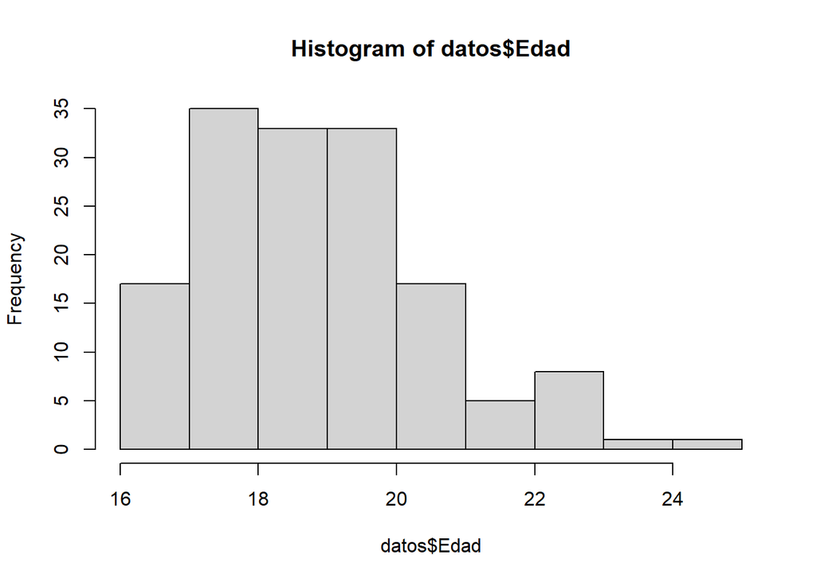

```r
# Gráficos para visualizar la distribución de los datos
hist(datos$Edad)
```

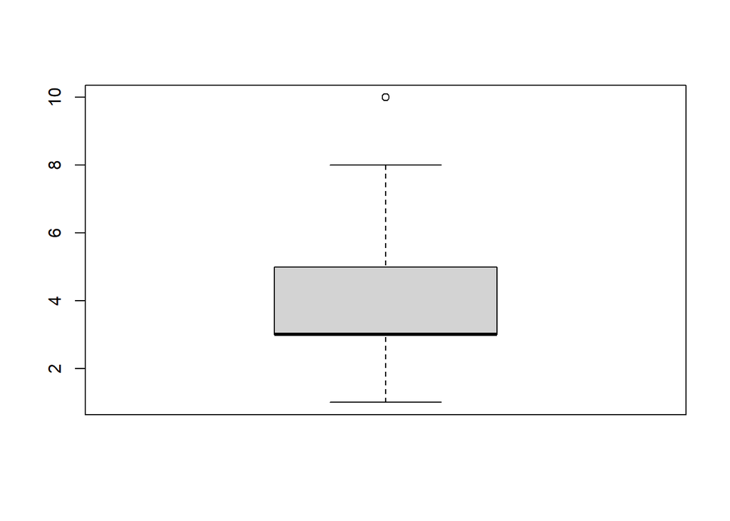

```r
boxplot(datos$Ciclo)
```

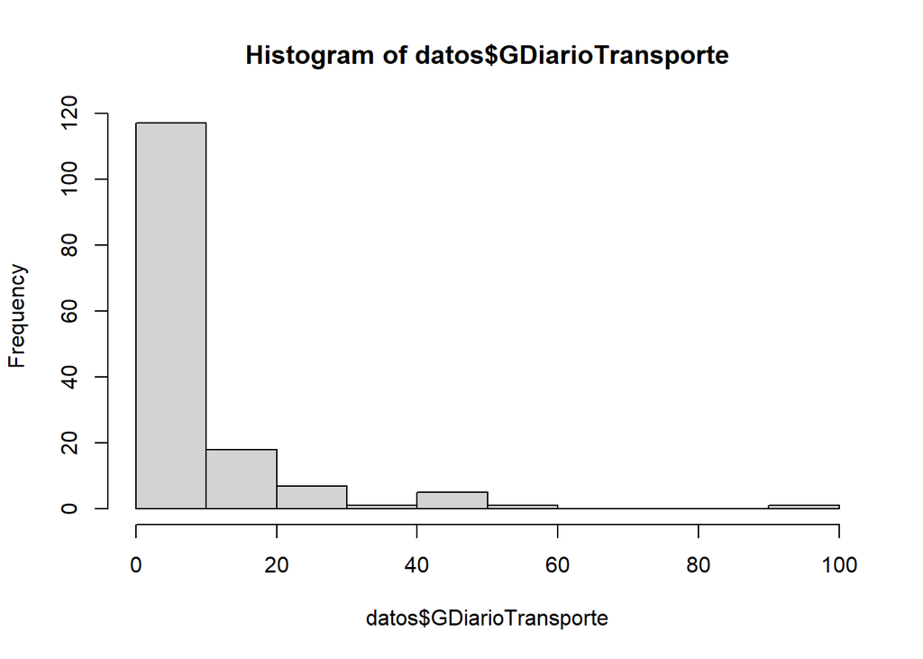

```r
hist(datos$GDiarioTransporte)
```

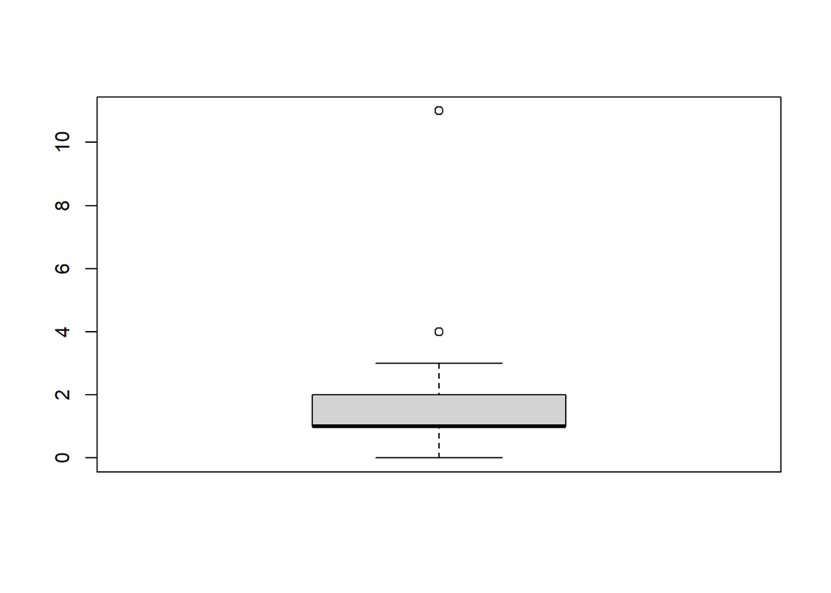

```r
boxplot(datos$CantTransportes)
```

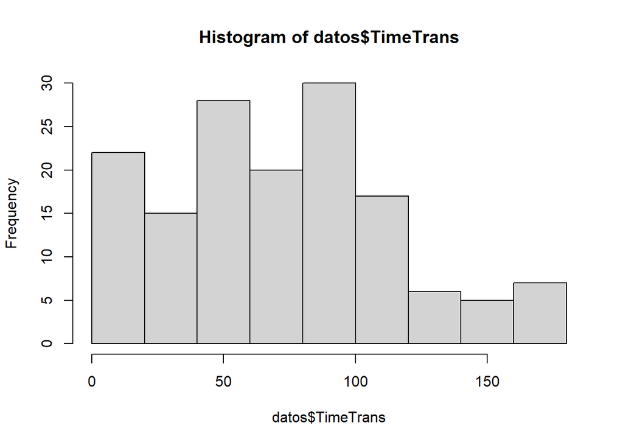

```r
hist(datos$TimeTrans)
```

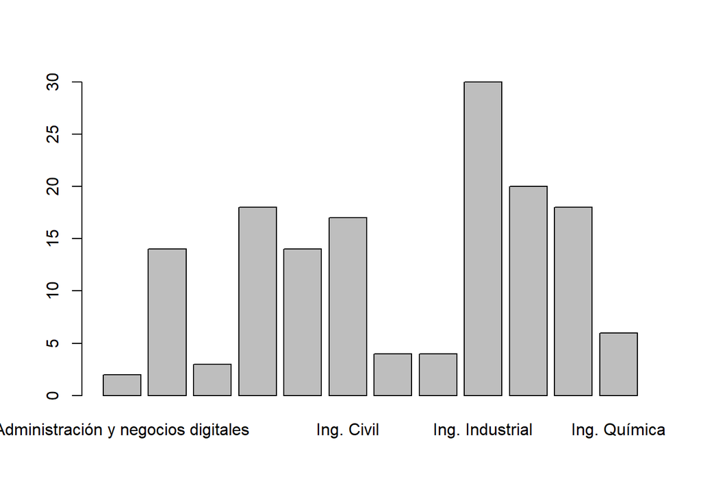

```r
barplot(table(datos$Carrera))
```

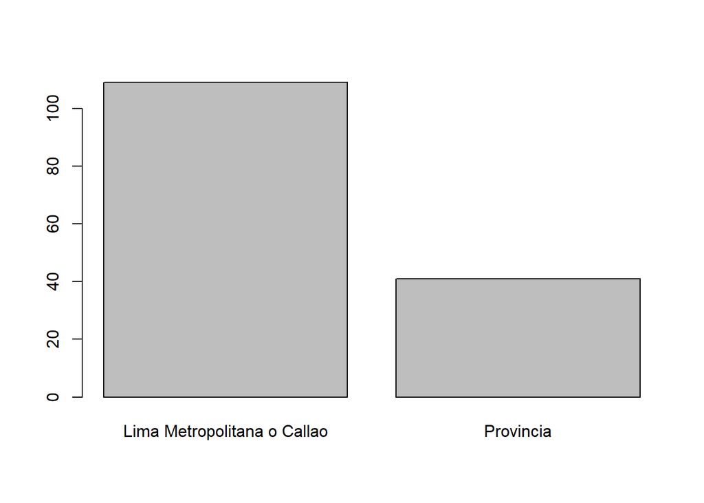

```r
barplot(table(datos$DProcedencia))
```

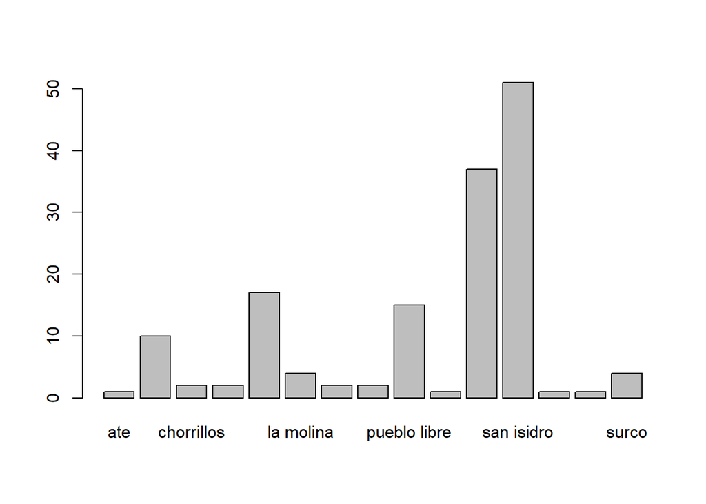

```r
barplot(table(datos$DSede))
```

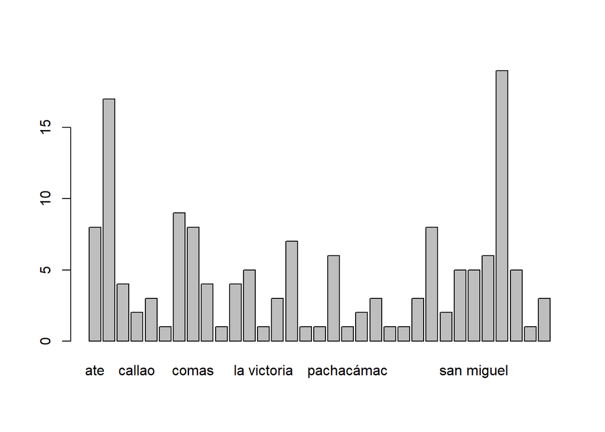

```r
barplot(table(datos$DResidencia))
```

En general, estos resultados nos dan una idea de las características generales del grupo de estudiantes y pueden ser útiles para tomar nuestro estudio.

# Análisis probabilistico

```r
# Cargando los datos
data <- read.csv("DataLimpia.csv")
```

## Probabilidad empirica:

Las probabilidades empíricas son una forma de estimar la probabilidad de que algo suceda basándose en datos que se han observado. Sin embargo, estas estimaciones pueden no ser exactas y pueden variar dependiendo de la información que se tenga disponible. Es importante tener en cuenta que siempre existe cierta incertidumbre en cualquier predicción o estimación de probabilidad.

Se eligieron dos variables (**DSede y DProcedencia**) porque ambas son discretas y categóricas, lo que permite determinar fácilmente el espacio de resultados teórico y calcular las probabilidades empíricas de cada evento atómico.

Se eligieron estas dos variables porque son fáciles de analizar y pueden proporcionar información útil sobre la composición de la población encuestada.

Además, estas variables pueden ser interesantes para analizar la composición de la población encuestada y cómo se distribuyen estas características entre los encuestados.

### Analisis de la variable “DSede”

```r
# Espacio de resultados teórico para la DSede
espacio_Dsede <- unique(data$DSede)
# Probabilidades empíricas para la carrera
prob_empirica_DSede <- table(data$DSede)/length(data$DSede)
```

```r
# Imprimiendo los resultados
espacio_Dsede
```

```
##  [1] "san isidro"        "pueblo libre"      "san borja"
##  [4] "jesÃºs marÃa"     "barranco"          "la molina"
##  [7] "comas"             "miraflores"        "los olivos"
## [10] "surco"             "santiago de surco" "puente piedra"
## [13] "chorrillos"        "santa anita"       "ate"
```

```r
prob_empirica_DSede
```

```
##
##               ate          barranco        chorrillos             comas
##       0.006666667       0.066666667       0.013333333       0.013333333
##     jesÃºs marÃa         la molina        los olivos        miraflores
##       0.113333333       0.026666667       0.013333333       0.013333333
##      pueblo libre     puente piedra         san borja        san isidro
##       0.100000000       0.006666667       0.246666667       0.340000000
##       santa anita santiago de surco             surco
##       0.006666667       0.006666667       0.026666667
```

### Analisis de la variable “DProcedencia”

```r
# Espacio de resultados teórico para el lugar de procedencia
espacio_procedencia <- unique(data$DProcedencia)

# Probabilidades empíricas para el lugar de procedencia
prob_empirica_procedencia <- table(data$DProcedencia)/length(data$DProcedencia)
```

Al analizar la variable lugar de procedencia, podemos determinar de dónde provienen la mayoría de los encuestados y cómo se distribuyen los diferentes lugares de procedencia en la población encuestada.

```r
# Imprimiendo los resultados
espacio_procedencia
```

```
## [1] "Provincia"                   "Lima Metropolitana o Callao"
```

```r
prob_empirica_procedencia
```

```
##
## Lima Metropolitana o Callao                   Provincia
##                   0.7266667                   0.2733333
```

### Analisis general

Probabilidad empírica: Para calcular la probabilidad empírica de dos variables, primero se necesita contar la frecuencia de cada combinación de variables y luego dividirla por el número total de observaciones.

- Contar frecuencias

  ```r
  tabla <- table(data$DSede, data$DProcedencia)
  tabla
  ```

  ```
  ##
  ##                     Lima Metropolitana o Callao Provincia
  ##   ate                                         1         0
  ##   barranco                                    6         4
  ##   chorrillos                                  1         1
  ##   comas                                       2         0
  ##   jesÃºs marÃa                              14         3
  ##   la molina                                   2         2
  ##   los olivos                                  2         0
  ##   miraflores                                  1         1
  ##   pueblo libre                               12         3
  ##   puente piedra                               1         0
  ##   san borja                                  27        10
  ##   san isidro                                 35        16
  ##   santa anita                                 1         0
  ##   santiago de surco                           1         0
  ##   surco                                       3         1
  ```

- Calcular probabilidad empírica

  ```r
  prob_empirica <- tabla / sum(tabla)
  prob_empirica
  ```

  ```
  ##
  ##                     Lima Metropolitana o Callao   Provincia
  ##   ate                               0.006666667 0.000000000
  ##   barranco                          0.040000000 0.026666667
  ##   chorrillos                        0.006666667 0.006666667
  ##   comas                             0.013333333 0.000000000
  ##   jesÃºs marÃa                     0.093333333 0.020000000
  ##   la molina                         0.013333333 0.013333333
  ##   los olivos                        0.013333333 0.000000000
  ##   miraflores                        0.006666667 0.006666667
  ##   pueblo libre                      0.080000000 0.020000000
  ##   puente piedra                     0.006666667 0.000000000
  ##   san borja                         0.180000000 0.066666667
  ##   san isidro                        0.233333333 0.106666667
  ##   santa anita                       0.006666667 0.000000000
  ##   santiago de surco                 0.006666667 0.000000000
  ##   surco                             0.020000000 0.006666667
  ```

### Aplicación

Para presentar ejemplos de análisis de probabilidad empírica, se podría calcular:

- La probabilidad de que un estudiante sea de “Lima Metropolitana o Callao” y prefiera el distrito de “San Isidro” como nueva sede de UTEC.

  ```r
  # Probabilidad de que un estudiante sea de "Lima Metropolitana o Callao" y prefiera "San Isidro"
  prob_lima_sanisidro <- prob_empirica["san isidro", "Lima Metropolitana o Callao"]
  prob_lima_sanisidro
  ```

  ```
  ## [1] 0.2333333
  ```

- La probabilidad de que un estudiante sea de provincia y prefiera el distrito de “ate” como nueva sede de UTEC.

  ```r
  # Probabilidad de que un estudiante sea de provincia y prefiera Ate
  prob_provincia_ate <- prob_empirica["ate", "Provincia"]
  prob_provincia_ate
  ```

  ```
  ## [1] 0
  ```

## Probabilidad condicional:

La probabilidad condicional es la probabilidad de que suceda un evento A, sabiendo que ya ha ocurrido el evento B. Se calcula dividiendo la probabilidad conjunta de los eventos A y B por la probabilidad del evento B. Es decir, P(A|B) = P(A y B) / P(B).

### Eventos dependientes e independientes

#### 1. Eventos dependientes

Un par de eventos que parece ser dependiente es la **cantidad de transportes** que usa el encuestado para llegar a UTEC y el **gasto aproximado diario en transporte**. Es probable que los encuestados que usan más transportes para llegar a UTEC también tengan un gasto diario más alto en transporte, lo que sugiere una relación entre los dos eventos.

##### 1.1. Analisis de verificación de dependencia

Calculando la probabilidad condicional de la cantidad de transportes dados los gastos diarios en transporte.

Se utiliza la función aggregate para calcular las probabilidades condicionales y conjuntas correspondientes. Luego, compara la probabilidad conjunta con el producto de las probabilidades individuales para determinar si los pares de eventos son dependientes o independientes.

```r
prob_condicional <- aggregate(data$CantTransportes, by = list(data$GDiarioTransporte), FUN = function(x) table(x)/length(x))
```

##### 1.2. Aplicación

Para el par de eventos dependientes, la cantidad de transportes que usa el encuestado para llegar a UTEC y el gasto aproximado diario en transporte:

- La probabilidad de que el encuestado use 2 transportes dado que tiene un gasto diario de transporte de S/10 es del 0.41.

- La probabilidad de que el encuestado use 3 transportes dado que tiene un gasto diario de transporte de S/10 es del 0.35.

- La probabilidad de que el encuestado use 4 transportes dado que tiene un gasto diario de transporte de S/10 es del 0.12.

```r
# Calcular probabilidades condicionales
prob_2_transportes <- data %>%
  filter(GDiarioTransporte == 10) %>%
  summarize(prob = mean(CantTransportes == 2))

prob_3_transportes <- data %>%
  filter(GDiarioTransporte == 10) %>%
  summarize(prob = mean(CantTransportes == 3))

prob_4_transportes <- data %>%
  filter(GDiarioTransporte == 10) %>%
  summarize(prob = mean(CantTransportes == 4))

# Imprimir resultados
prob_2_transportes$prob
```

```
## [1] 0.4117647
```

```r
prob_3_transportes$prob
```

```
## [1] 0.3529412
```

```r
prob_4_transportes$prob
```

```
## [1] 0.1176471
```

##### 1.3. Conclusión

Estos resultados sugieren que hay una relación entre la cantidad de transportes que usa el encuestado para llegar a UTEC y el gasto aproximado diario en transporte, lo que indica que estos eventos son dependientes.

#### 2. Eventos independientes

Un par de eventos que parecen ser independientes es la **carrera** a la que pertenece el encuestado y el **lugar de donde procede**. No hay una relación clara entre estos dos eventos, ya que los estudiantes de cualquier carrera pueden proceder de Lima o de provincia.

##### 2.1. Analisis de eventos independientes

- Calculando la probabilidad conjunta de la carrera y el lugar de procedencia

  ```r
  # Calculando la probabilidad conjunta de la carrera y el lugar de procedencia
  prob_conjunta <- aggregate(data$Carrera, by = list(data$DProcedencia), FUN = function(x) table(x)/length(x))
  ```

- Probabilidad individual para la variable “Carrera”

  ```r
  prob_individual_carrera <- table(data$Carrera)/length(data$Carrera)
  prob_individual_carrera
  ```

  ```
  ##
  ## AdministraciÃ³n y negocios digitales                       BioingenierÃa
  ##                           0.01333333                           0.09333333
  ##                    Ciencias de datos          Ciencias de la computaciÃ³n
  ##                           0.02000000                           0.12000000
  ##                       Ing. Ambiental                           Ing. Civil
  ##                           0.09333333                           0.11333333
  ##                     Ing. de EnergÃa                    Ing. ElectrÃ³nica
  ##                           0.02666667                           0.02666667
  ##                      Ing. Industrial                       Ing. MecÃ¡nica
  ##                           0.20000000                           0.13333333
  ##                    Ing. MecatrÃ³nica                        Ing. QuÃmica
  ##                           0.12000000                           0.04000000
  ```

- Probabilidad individual para la variable “DProcedencia”

  ```r
  prob_individual_procedencia <- table(data$DProcedencia)/length(data$DProcedencia)
  prob_individual_procedencia
  ```

  ```
  ##
  ## Lima Metropolitana o Callao                   Provincia
  ##                   0.7266667                   0.2733333
  ```

- Probabilidad conjunta del productos de probabilidades individuales de las variable “Carrera” y “DProcedencia”

  ```r
  prob_conjunta_producto <- outer(prob_individual_carrera,prob_individual_procedencia)
  prob_conjunta_producto
  ```

  ```
  ##
  ##                                        Lima Metropolitana o Callao   Provincia
  ##   AdministraciÃ³n y negocios digitales                 0.009688889 0.003644444
  ##   BioingenierÃa                                       0.067822222 0.025511111
  ##   Ciencias de datos                                    0.014533333 0.005466667
  ##   Ciencias de la computaciÃ³n                          0.087200000 0.032800000
  ##   Ing. Ambiental                                       0.067822222 0.025511111
  ##   Ing. Civil                                           0.082355556 0.030977778
  ##   Ing. de EnergÃa                                     0.019377778 0.007288889
  ##   Ing. ElectrÃ³nica                                    0.019377778 0.007288889
  ##   Ing. Industrial                                      0.145333333 0.054666667
  ##   Ing. MecÃ¡nica                                       0.096888889 0.036444444
  ##   Ing. MecatrÃ³nica                                    0.087200000 0.032800000
  ##   Ing. QuÃmica                                        0.029066667 0.010933333
  ```

Comparando la **probabilidad conjunta** con el **producto de las probabilidades individuales**

```r
# Comparando la probabilidad conjunta con el producto de las probabilidades individuales
all.equal(prob_conjunta, prob_conjunta_producto)
```

```
##  [1] "Modes: list, numeric"
##  [2] "Lengths: 2, 24"
##  [3] "names for target but not for current"
##  [4] "Attributes: < Names: 2 string mismatches >"
##  [5] "Attributes: < Component 1: Modes: character, numeric >"
##  [6] "Attributes: < Component 1: Lengths: 1, 2 >"
##  [7] "Attributes: < Component 1: target is character, current is numeric >"
##  [8] "Attributes: < Component 2: Modes: numeric, list >"
##  [9] "Attributes: < Component 2: names for current but not for target >"
## [10] "Attributes: < Component 2: target is numeric, current is list >"
## [11] "current is not list-like"
```

##### 2.2. Aplicación

- La probabilidad conjunta de que el encuestado pertenezca a la carrera de Ingeniería Civil y proceda de Lima es del 0.06
- La probabilidad individual de que el encuestado pertenezca a la carrera de Ingeniería Civil es del 0.113.
- La probabilidad individual de que el encuestado proceda de Lima es del 0.726.

```r
# Calcular probabilidad conjunta
prob_conjunta <- data %>%
  summarize(prob = mean(Carrera == "Ing. Civil" & DProcedencia == "Lima Metropolitana o Callao"))

# Calcular probabilidades individuales
prob_carrera <- data %>%
  summarize(prob = mean(Carrera == "Ing. Civil"))

prob_procedencia <- data %>%
  summarize(prob = mean(DProcedencia == "Lima Metropolitana o Callao"))

# Imprimir resultados
prob_conjunta$prob
```

```
## [1] 0.06
```

```r
prob_carrera$prob
```

```
## [1] 0.1133333
```

```r
prob_procedencia$prob
```

```
## [1] 0.7266667
```

```r
prob_conjunta_productos <- outer(prob_carrera$prob,prob_procedencia$prob)
prob_conjunta_productos
```

```
##            [,1]
## [1,] 0.08235556
```

## Variables discretas:

Aqui podemos encontrar algunas variables discretas como lo son en el estudio la variable edad y la variable cantidad de transportes.

1. Variable Edad

Construccion del ejemplo.

Se llega a un hipotético caso de que los padres de los menores de edad son los que van a tomar las desiciones de la economía del hogar y determinarán si les conviene seguir pagando los mismos pasajes. Por ende se La edad puede proporcionar información sobre las necesidades y requisitos de las personas en diferentes etapas de la vida. Por ejemplo, los alumnos mayores pueden tener requisitos de accesibilidad o comodidades específicas, mientras que los jóvenes pueden tener necesidades relacionadas con la tecnología o el entretenimiento. Comprender la edad de la población objetivo puede ayudar a diseñar la nueva sede para satisfacer esas necesidades específicas. Se sabe que Los alumnos más adultos[20 años - adelante] prefieren zonas con más comodidad mientras que los estudiantes jóvenes [16 años -19 años] gustan áreas más lúdicas o con relación con la tecnología.:

```r
XD <- data.frame(table(datos$Edad))
```

1. Definir el tipo de distribución que se usará:

```r
CME <- XD[1,2] + XD[2,2] + XD[3,2] + XD[4,2]
print("Alumnos jóvenes")
```

```
## [1] "Alumnos jóvenes"
```

```r
CME
```

```
## [1] 85
```

```r
print("Alumnos adultos")
```

```
## [1] "Alumnos adultos"
```

```r
CAA <- sum(XD$Freq) - CME
CAA
```

```
## [1] 65
```

Ubicamos su porcentaje de edad

```r
TOT <- sum(XD$Freq)
p_jovenes <- CME/TOT
print("Probabilidad de que sean alumnos jóvenes")
```

```
## [1] "Probabilidad de que sean alumnos jóvenes"
```

```r
p_jovenes
```

```
## [1] 0.5666667
```

```r
p_alum_mayores <- 1 - (p_jovenes)
print("Probabilidad de que sean alumnos adultos")
```

```
## [1] "Probabilidad de que sean alumnos adultos"
```

```r
p_alum_mayores
```

```
## [1] 0.4333333
```

2. Construccion de la densidad con la distribución binomial.

Se termina hallando que el 4.65% se inclinan mas por las comodidades que por las tecnologías y viceversa.

```r
dbinom(70,TOT,p_alum_mayores)
```

```
## [1] 0.04650727
```

```r
dbinom(80,TOT,p_jovenes)
```

```
## [1] 0.04650727
```

3. Contrucción del grafico en función a la densidad.

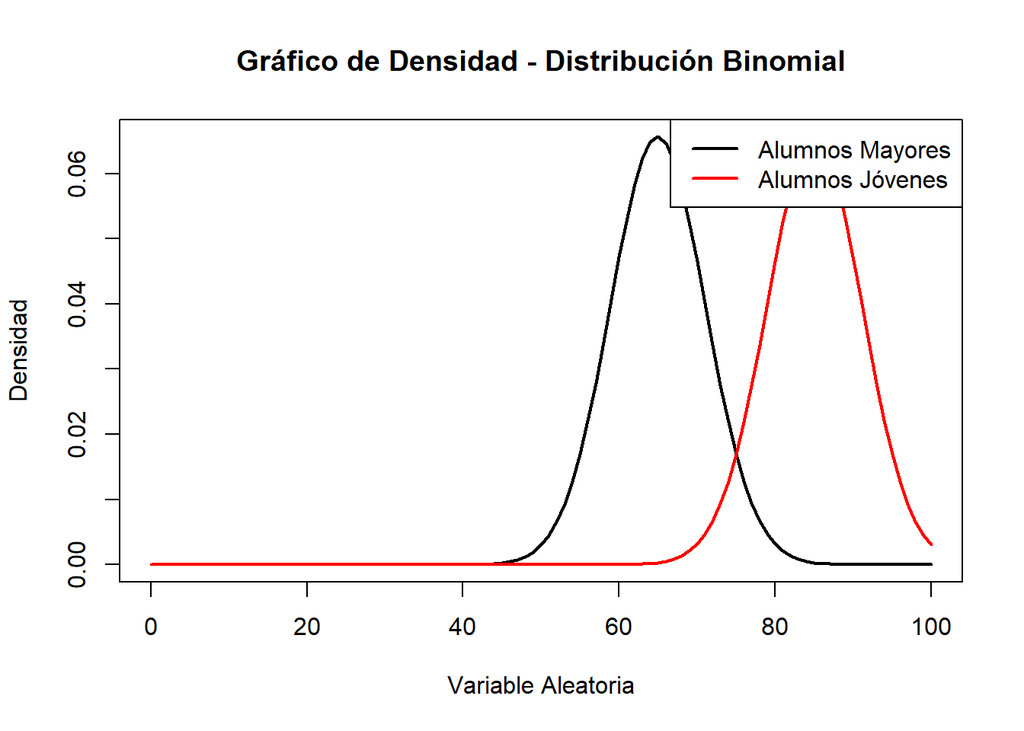

```r
# Definir nuestros parámetros
k <- 0:100

# Calcular las probabilidades para cada valor de k utilizando dbinom
prob_alum_mayores <- dbinom(k, size = TOT, prob = p_alum_mayores)
prob_jovenes <- dbinom(k, size = TOT, prob = p_jovenes)

# Crear el gráfico de densidad
plot(k, prob_alum_mayores, type = "l", xlab = "Variable Aleatoria", ylab = "Densidad",
     main = "Gráfico de Densidad - Distribución Binomial", lwd = 2)
lines(k, prob_jovenes, col = "red", lwd = 2)
legend("topright", legend = c("Alumnos Mayores", "Alumnos Jóvenes"), col = c("black", "red"), lwd = 2)
```

2. Variable “CantTransportes”

   Construccion del ejemplo:

   Se debe realizar un estudio de cuánto es la probabilidad de que se haga uso de 15 o más transportes para llegar a UTEC semanalmente.
1. Hallar el promedio diario de uso de transportes.

```r
prom_trans <- mean(data$CantTransportes)
print(round(prom_trans))
```

```
## [1] 2
```

Se hace una regla de 3 simple para poder identificar el valor promedio de transportes usados en una semana. cant.horas prom.cantidad trans.  
24 <———–> 2

“x” ha sido identificada como la variable “SM” (“promedio de uso de transportes por semana”)

```r
SM <- round((168*round(prom_trans))/24)
SM
```

```
## [1] 14
```

2. Aplicación de distribución de Poisson

Se aplicó una distribución de Poisson, ya que se requiere contar el número de veces que se produce dicho suceso aleatorio durante un periodo determinado de tiempo, por lo que se decidió buscar La probabilidad de uso de 15 o más transportes semanales.

```r
#La probabilidad de que usen 15 o más cantidad de transportes es de un 43%
prob <- round(ppois(14,SM,lower.tail=F),3)
prob
```

```
## [1] 0.43
```

```r
#El porcentaje resulta la variable prob * 100%
PP <- prob * 100
PP
```

```
## [1] 43
```

Por lo tanto, la probabilidad de que de que usen 15 o más transportes es de 43%. Por consiguiente se realiza el siguiente gráfico

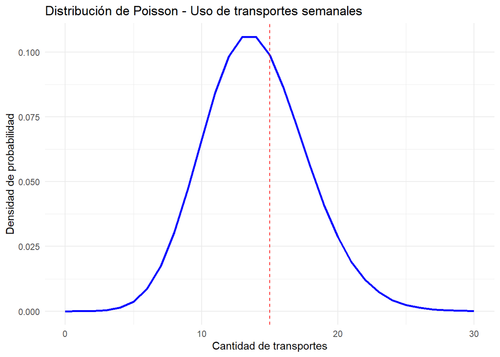

```r
library(ggplot2)
# Se establece unos parámetros para ubicar mis variables
x <- 0:30
# Calculamos la densidad de probabilidad utilizando la función dpois
densidad <- dpois(x, SM)
# Establecemos un data frame con los valores de x y la densidad de probabilidad
df <- data.frame(x = x, densidad = densidad)
# Creamos el gráfico de densidad utilizando ggplot2
ggplot(df, aes(x, densidad)) +
  geom_line(color = "blue", size = 1) +
  geom_vline(xintercept = 15, linetype = "dashed", color = "red") +
  labs(x = "Cantidad de transportes", y = "Densidad de probabilidad") +
  ggtitle("Distribución de Poisson - Uso de transportes semanales") +
  theme_minimal()
```

## Variables continuas:

Para el estudio de las variables continuas “GDiarioTransporte” y “TimeTrans”.

1. Calcularemos la esperanza y la variación con la distribución normal.

```r
# Calcular la Esperanza(E) y la Varianza(V) para GDiarioTransporte

    # 1) GDiarioTransporte
    Media1 <- mean(data$GDiarioTransporte)
    Desviación1 <- sd(data$GDiarioTransporte)
    maximo1 <- max(data$GDiarioTransporte)
    minimo1 <- min(data$GDiarioTransporte)

    #Esperanza
    EGD <- Media1
    EGD
```

```
## [1] 9.55
```

```r
    #Variación
    VGD <- (Desviación1)^2
    VGD
```

```
## [1] 185.2408
```

```r
# Calcular la Esperanza(E) y la Varianza(V) para  TimeTrans
    # 2)TimeTrans
    Media2 <- mean(data$TimeTrans)
    Desviacion2 <- sd(data$TimeTrans)
    maximo2 <- max(data$TimeTrans)
    minimo2 <- min(data$TimeTrans)

    #Esperanza
    ETT <- Media2
    ETT
```

```
## [1] 77.27333
```

```r
    #Variación
    VTT <- (Desviacion2)^2
    VTT
```

```
## [1] 1947.878
```

2. Implementar un ejemplo para cada variable

```r
 # 1) Ejemplo para GDiarioTrans

  #Para el GDiarioTrans indicaremos cual es la probabilidad de que las personas gasten más de 50 soles.
  probabilidad1 <- (pnorm(50,Media1,Desviación1,lower.tail=F))
  probabilidad1*100
```

```
## [1] 0.1479286
```

```r
# 2) Ejemplo para TimeTrans

  #Para el TimeTras indicaremos cual es la probabilidad de que las personas se demoran más 60 minutos en llegar a la Utec.
  probabilidad2 <- (pnorm(60,Media2,Desviacion2,lower.tail=F))
  probabilidad2*100
```

```
## [1] 65.22407
```

3. Implemetar el grafico de la densidad de la distribución normal
- Grafico de la densidad de la distribucion normal de GDiarioTrans

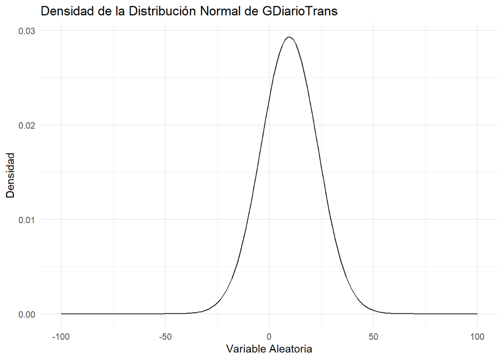

  ```r
    # 1) Calcular la densidad de las variables.
    # 2) Crear una Grafica de la densidad de la distribucion normal

      # Densidad de GDiariTrans
      x1 <- seq(-maximo1,maximo1,length.out = 150)
      densidad1 <- dnorm(x1,Media1,Desviación1)

      #Grafico de la densidad de la distribucion normal de GDiarioTrans

      df <- data.frame(x = x1, densidad = densidad1)
      ggplot(df, aes(x = x, y = densidad)) +
        geom_line() +
        labs(title = "Densidad de la Distribución Normal de GDiarioTrans",
             x = "Variable Aleatoria",
             y = "Densidad") +
        theme_minimal()
  ```

- Grafico de la densidad de la distribucion normal de TimeTrans

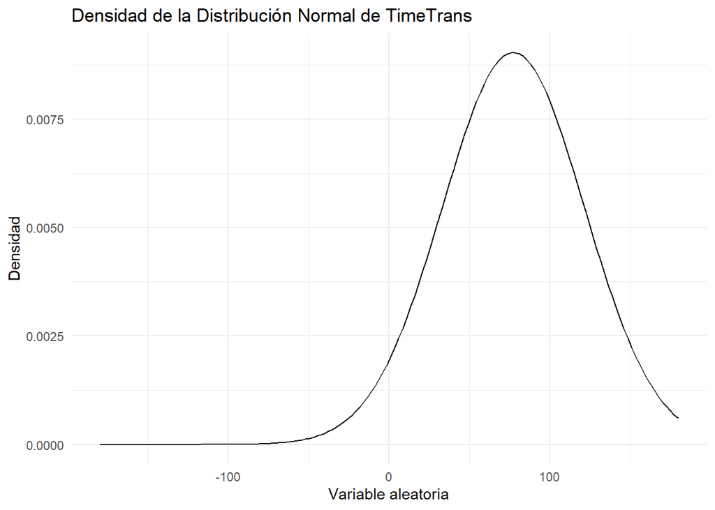

  ```r
    # 1) Calcular la densidad de las variables.
    # 2) Crear una Grafica de la densidad de la distribucion normal
      # Densidad de TimeTrans
      x2 <- seq(-maximo2,maximo2,length.out = 150)
      densidad2 <- dnorm(x2,Media2,Desviacion2)

      #Grafico de la densidad de la distribucion normal de TimeTrans

      df <- data.frame(x = x2, densidad = densidad2)
      ggplot(df, aes(x = x, y = densidad)) +
        geom_line() +
        labs(title = "Densidad de la Distribución Normal de TimeTrans",
             x = "Variable aleatoria",
             y = "Densidad") +
        theme_minimal()
  ```

En clusión, para el caso de las variables continuas, para la variable de GDiarioTrans se puede afirmar que al calcular la probabilidad se define que el 0.147% gasta más de 50 soles. Para el caso de la variable Time Trans que al calcular la probabilidad se define que más del 65% se demora más de 60 minutos

# Conlusiones generales:

La encuesta realizada proporcionó información valiosa sobre las características de los estudiantes encuestados y sus preferencias en cuanto a la ubicación y las características de los espacios en la nueva sede de la universidad.

En cuanto a las variables de transporte, se encontró que la mayoría de los estudiantes utiliza uno o dos transportes por día, y que el tiempo promedio de transporte es de 77.27 minutos, aunque hay una gran variabilidad en los datos. Además, se encontró que el gasto diario en transporte varía ampliamente entre los estudiantes encuestados.

En cuanto a las preferencias de ubicación, se encontró que la mayoría de los estudiantes prefieren una ubicación céntrica para la nueva sede de la universidad. En cuanto a las características de los espacios verdes y para discapacitados, se encontró que los estudiantes otorgan una calificación promedio alta a ambos tipos de espacios.

Para identificar los beneficios de la nueva sede y cómo afectaría a los alumnos, se puede considerar que la ubicación en un distrito con alta calidad de espacios verdes y para discapacitados puede mejorar la calidad de vida y el bienestar de los estudiantes. Además, la ubicación céntrica y cercana a lugares de estudio puede facilitar el acceso y el desplazamiento de los estudiantes.

Para identificar las estructuras o áreas que podría tener la nueva sede para los alumnos, para sus actividades diarias, se puede considerar que se deben incluir espacios verdes y para discapacitados de alta calidad, así como áreas comunes y espacios de aprendizaje innovadores y accesibles. Además, se debe tener en cuenta la ubicación céntrica y cercana a lugares de estudio para facilitar el acceso y el desplazamiento de los estudiantes.

En conclusión, el análisis descriptivo y probabilístico realizado proporciona información valiosa sobre las características de los estudiantes encuestados y sus preferencias en cuanto a la ubicación y las características de los espacios en la nueva sede. Los resultados muestran que los estudiantes prefieren una ubicación céntrica y otorgan una calificación alta a los espacios de áreas verdes y para discapacitados. Además, se identificó que los distritos de San Borja y San Isidro son los más preferidos por los estudiantes para la ubicación de la nueva sede. Estos resultados pueden ser útiles para guiar futuras investigaciones y planes de desarrollo, y para tomar decisiones informadas sobre la ubicación y las características de la nueva sede de la universidad.